# All Countries Environmental Data

# Multiple Factor Analyis

## Description

Multiple factor analysis is an extension of PCA tailored to handle multiple datatables that measure sets of variables collected on the same observations. MFA proceeds in two steps 1. It computes a PCA of each data table and ‘normalizes’ each data table by dividing all its elements by the ﬁrst singular value obtained from its PCA. 2. All the normalized data tables are aggregated into a grand data table that is analyzed via a (non-normalized) PCA that gives a set of factor scores for the observations and loadings for the variables.

In addition, MFA provides for each data table a set of partial factor scores for the observations that reﬂects the speciﬁc ‘view-point’ of this data table. Interestingly, the common factor scores could be obtained by replacing the original normalized data tables by the normalized factor scores obtained from the PCA of each of these tables.

## MFA

We have divided the data into 3 tables, separate tables for rain and temperature related columns and 3rd table for rest of the columns.

```
[1] "Preprocessed the Rows of the data matrix using:  None"
[1] "Preprocessed the Columns of the data matrix using:  Center_1Norm"
[1] "Preprocessed the Tables of the data matrix using:  MFA_Normalization"
[1] "Preprocessing Completed"
[1] "Optimizing using:  None"
[1] "Processing Complete"
```

## Scree Plot

Gives amount of information explained by corresponding component. Gives an intuition to decide which components best represent data in order to answer the research question.

P.S. The most contribution component may not always be most useful for a given research question.

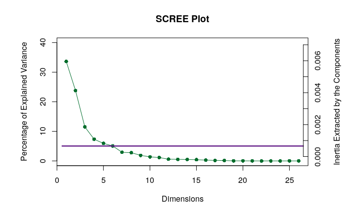

## Factor Scores

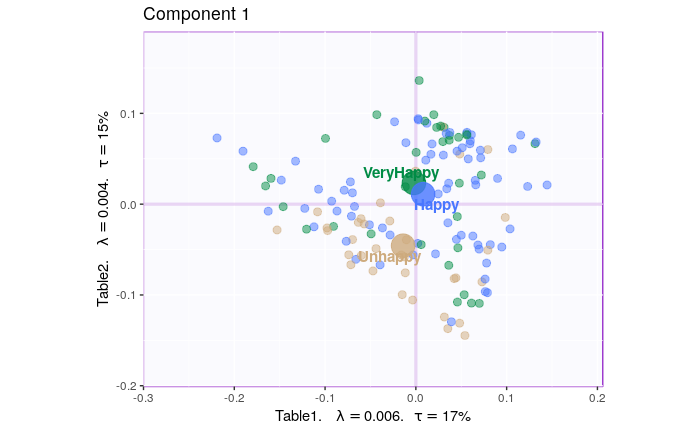

- With Tolerance Interval

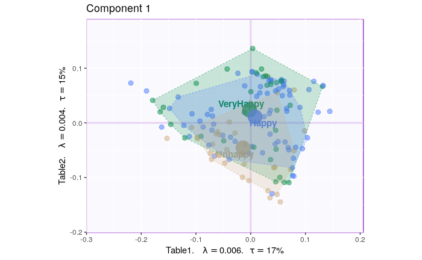

- With Partial Factor Scores

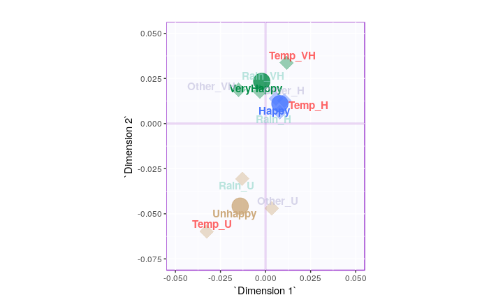

## Loadings

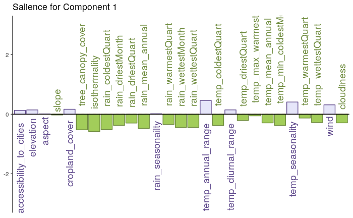

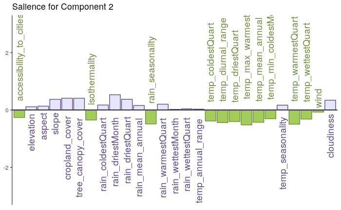

## Correlation Circle

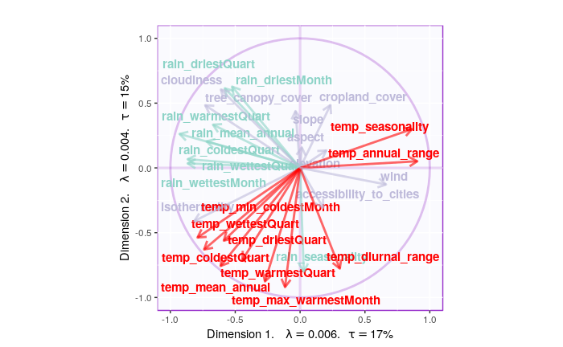

## Conclusion

| **Methods** | **Unhappy** | **Normal** | **Very Happy** | **Reliability** |
| --- | --- | --- | --- | --- |
| **MFA** | Partial factors dominated by Temp, then rain and other variables | Neither of partial factors seems to have sufficient effect | Partial factors dominated by Temp and other variables, lesser effect of rain | Convex hull has overlapping areas |